# My Spotify project on the coolness of Radiohead

Author

Durdane Sahin

# Welcome to my Spotify project about Radiohead :)

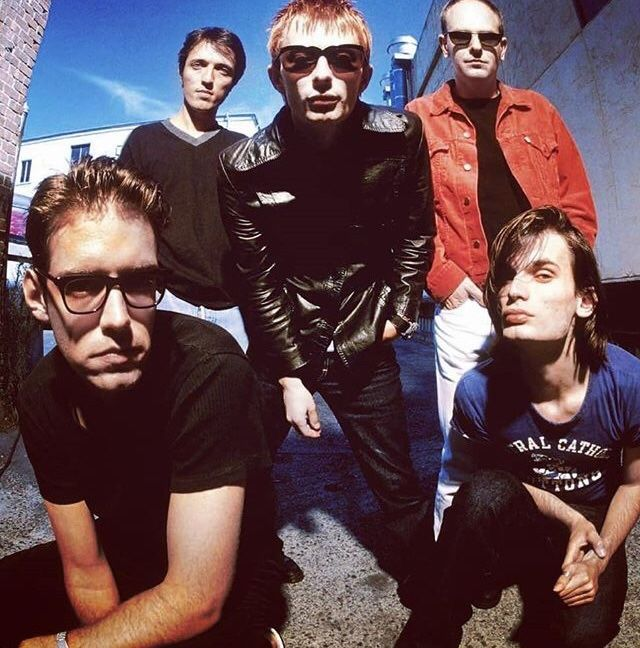

**Radiohead being cool in the 90s**

#### Who are they?

Radiohead is great.

They are an English band, formed in 1985. They are considered an experimental, alt-rock group.

#### **Radiohead’s top 3 albums:**

1. OK COMPUTER

2. KID A

3. In Rainbows

#### My current favorite song:

[Jigsaw Falling Into Place](https://www.youtube.com/watch?v=GoLJJRIWCLU&list=RDGoLJJRIWCLU&start_radio=1)

[video not shown]

My current second favorite song:  
[Weird Fishes/Arpeggi](https://www.youtube.com/watch?v=FcANFVcJeOM&list=RDFcANFVcJeOM&start_radio=1)

[video not shown]

### **Data analysis**

First, I had to install several packages. I extracted data using the spotifyr package and stored it in a data folder called myData.

```r
library(ggplot2)
library(dplyr)
library(readr)
myData <- read.csv("Radiohead.csv")
```

Then, I filtered some albums that I liked and was interested in. The data was stored under the name selected_albums. Now, I can use the selected albums for my analysis.

```r
selected_albums <- myData |>
  filter(album_name %in% c(
    "In Rainbows",
    "OK Computer",
    "The Bends",
    "Hail To The Thief",
    "KID A MNESIA",
    "Pablo Honey"
  ))
```

Firstly, I look at the loudness and energy of the albums. A few songs are quiet, but most of them are pretty loud.

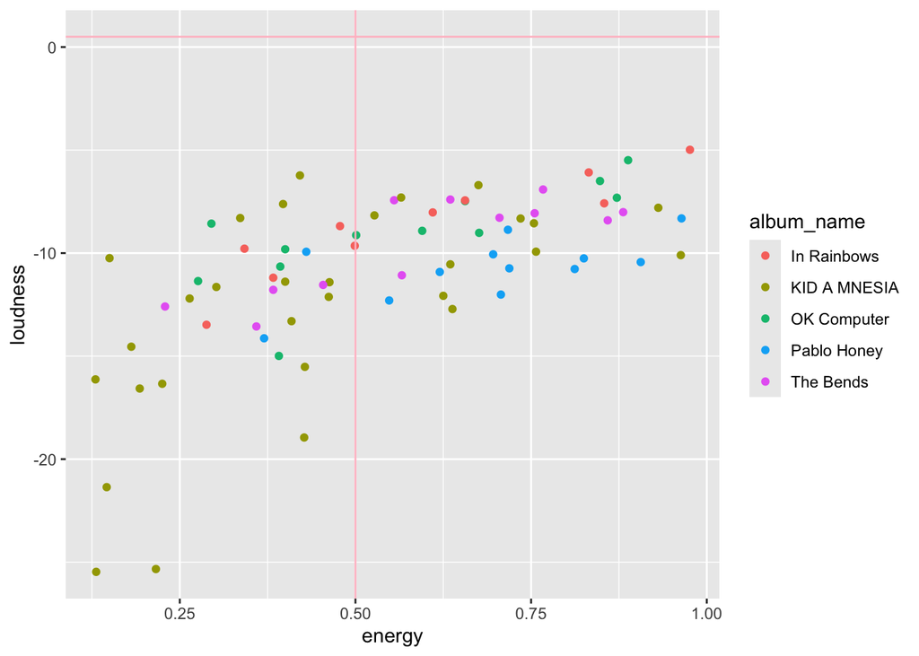

```r
ggplot(selected_albums, aes(x = energy, y = loudness, color = album_name)) + geom_point()+
  geom_hline(yintercept = 0.5, color="pink") +
  geom_vline(xintercept = 0.5, color="pink")
```

Then, I wanted to see where the songs are on the energy and valence category. My current favorite song is the 2nd happiest song and has lots of energy! Still, we can see that most of their songs are more sad and low-medium energy.

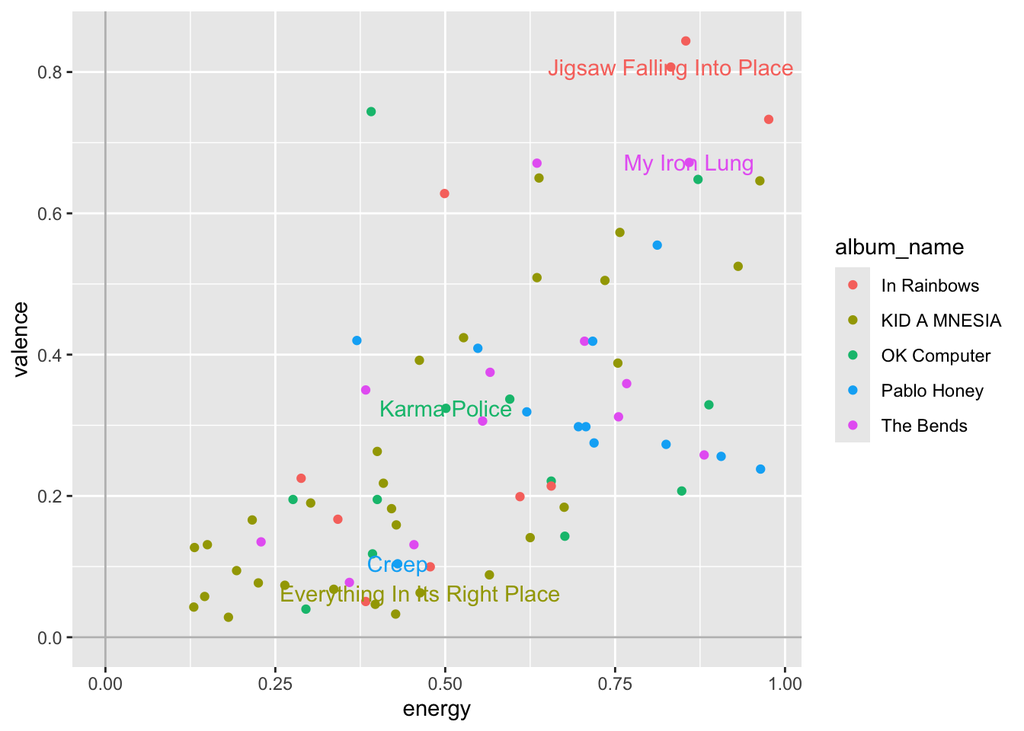

```r
subgroup <- selected_albums |> filter(track_name %in% c("My Iron Lung", "Creep",  "Karma Police", "Jigsaw Falling Into Place", "Everything In Its Right Place"))
ggplot(selected_albums, aes(x = energy, y = valence, color = album_name))+
 geom_point()+
 geom_hline(yintercept = 0, color="grey")+
 geom_vline(xintercept = 0, color="grey")+
  geom_text(data = subgroup,
            aes (label = track_name),
            show.legend = FALSE)
```

Then, i look at loudness and energy. The graph shows an upwards slope, which means the louder the songs get, the more energy they have.

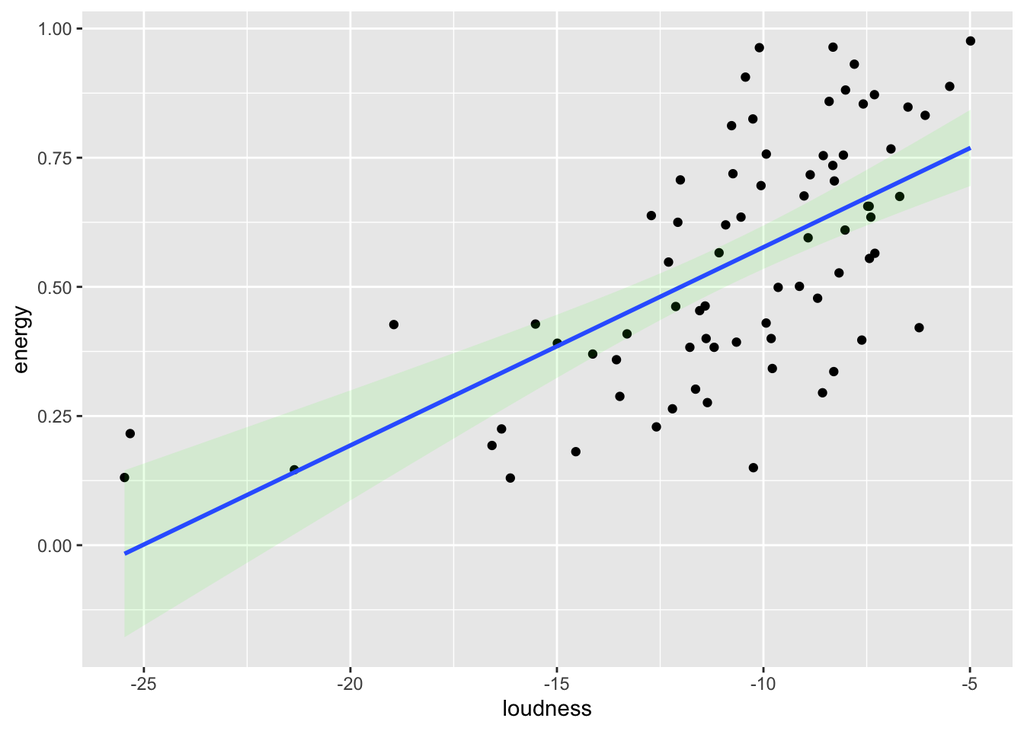

```r
ggplot(selected_albums, aes(x = loudness, y = energy)) +
  geom_point() +
  geom_smooth(method = "lm", alpha = 0.1, fill ="green")
```

Then, I compared the tempo of different albums. The blue bars show the relative density/frequency of tempos. Peaks above 120 BPM means that the album has faster songs. Below that means slower songs.

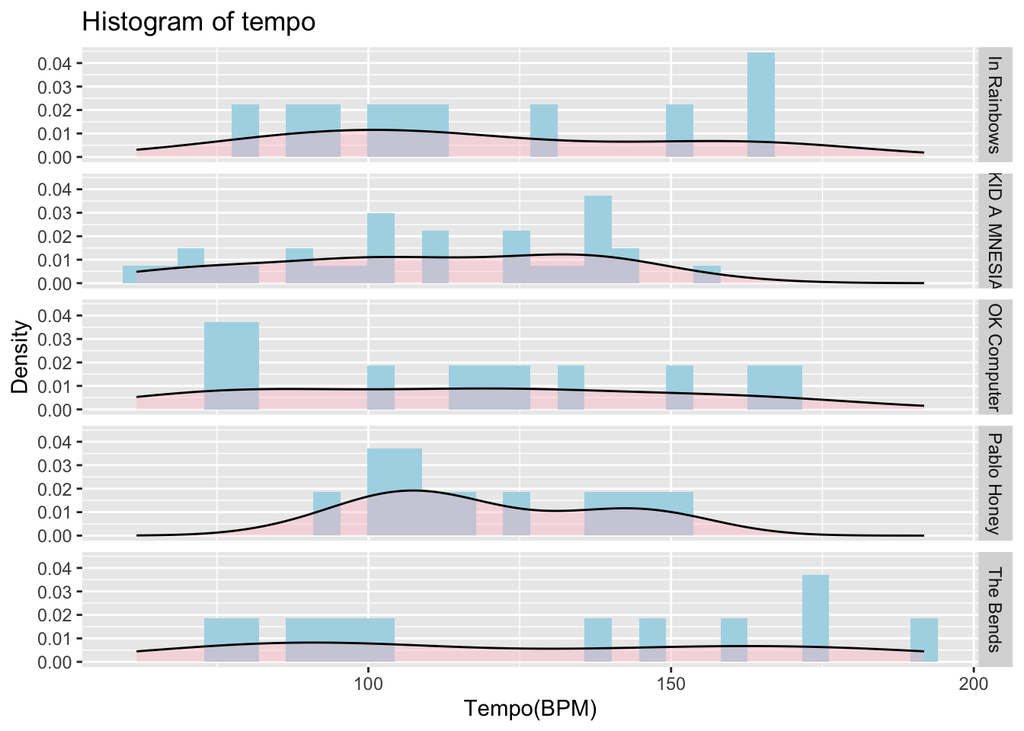

```r
ggplot(selected_albums, aes(x=tempo))+
 geom_histogram(aes(y=..density..), fill="lightblue")+
 geom_density(fill="pink", alpha= 0.4)+
 facet_grid(album_name ~ .)+
 labs(title="Histogram of tempo", x="Tempo(BPM)", y="Density")
```

Here are their happiest songs:

```r
selected_albums |> slice_max(valence, n=3) |> dplyr::select(track_name, album_name, album_release_year, valence) |> knitr::kable(digits = 2)
```

| track_name | album_name | album_release_year | valence |
| --- | --- | --- | --- |
| 15 Step | In Rainbows | 2007 | 0.84 |
| Jigsaw Falling Into Place | In Rainbows | 2007 | 0.81 |
| Fitter Happier | OK Computer | 1997 | 0.74 |

Danceability is not something that is quickly associated with Radiohead, so I wanted to see which songs are the most danceable. I disagree with these findings…

```r
selected_albums |> slice_max(danceability, n=3) |> dplyr::select(track_name, album_name, album_release_year, danceability) |> knitr::kable(digits = 2)
```

| track_name | album_name | album_release_year | danceability |
| --- | --- | --- | --- |
| House Of Cards | In Rainbows | 2007 | 0.71 |
| All I Need | In Rainbows | 2007 | 0.67 |
| Packt Like Sardines In a Crushd Tin Box | KID A MNESIA | 2021 | 0.67 |